# MEDICAL_COST_PREDICTION

## Problem Statement - The aim here will be to predict the medical costs billed by health insurance on an individual given some features about the individual in the dataset.

```python
import pandas as pd
import numpy as np
import seaborn as sns
import matplotlib.pyplot as plt
```

## Step - 1: Load the data and perform the basic EDA to understand the data.

```python
df = pd.read_csv(r"insurance.csv")

df
```

|  | age | sex | bmi | children | smoker | region | charges |
| --- | --- | --- | --- | --- | --- | --- | --- |
| 0 | 19 | female | 27.900 | 0 | yes | southwest | 16884.92400 |
| 1 | 18 | male | 33.770 | 1 | no | southeast | 1725.55230 |
| 2 | 28 | male | 33.000 | 3 | no | southeast | 4449.46200 |
| 3 | 33 | male | 22.705 | 0 | no | northwest | 21984.47061 |
| 4 | 32 | male | 28.880 | 0 | no | northwest | 3866.85520 |
| ... | ... | ... | ... | ... | ... | ... | ... |
| 1333 | 50 | male | 30.970 | 3 | no | northwest | 10600.54830 |
| 1334 | 18 | female | 31.920 | 0 | no | northeast | 2205.98080 |
| 1335 | 18 | female | 36.850 | 0 | no | southeast | 1629.83350 |
| 1336 | 21 | female | 25.800 | 0 | no | southwest | 2007.94500 |
| 1337 | 61 | female | 29.070 | 0 | yes | northwest | 29141.36030 |

1338 rows × 7 columns

```python
df.columns
```

```
Index(['age', 'sex', 'bmi', 'children', 'smoker', 'region', 'charges'], dtype='object')
```

## Exploratory Data Analysis

```python
df.isnull().sum()
```

```
age         0
sex         0
bmi         0
children    0
smoker      0
region      0
charges     0
dtype: int64
```

## Identifying the duplicates

```python
df.duplicated().value_counts()
```

```
False    1337
True        1
Name: count, dtype: int64
```

```python
df.drop_duplicates(inplace=True)
```

```python
df = df.reset_index().drop(columns="index")
df
```

|  | age | sex | bmi | children | smoker | region | charges |
| --- | --- | --- | --- | --- | --- | --- | --- |
| 0 | 19 | female | 27.900 | 0 | yes | southwest | 16884.92400 |
| 1 | 18 | male | 33.770 | 1 | no | southeast | 1725.55230 |
| 2 | 28 | male | 33.000 | 3 | no | southeast | 4449.46200 |
| 3 | 33 | male | 22.705 | 0 | no | northwest | 21984.47061 |
| 4 | 32 | male | 28.880 | 0 | no | northwest | 3866.85520 |
| ... | ... | ... | ... | ... | ... | ... | ... |
| 1332 | 50 | male | 30.970 | 3 | no | northwest | 10600.54830 |
| 1333 | 18 | female | 31.920 | 0 | no | northeast | 2205.98080 |
| 1334 | 18 | female | 36.850 | 0 | no | southeast | 1629.83350 |
| 1335 | 21 | female | 25.800 | 0 | no | southwest | 2007.94500 |
| 1336 | 61 | female | 29.070 | 0 | yes | northwest | 29141.36030 |

1337 rows × 7 columns

```python
df.isna().sum()
```

```
age         0
sex         0
bmi         0
children    0
smoker      0
region      0
charges     0
dtype: int64
```

```python
df.info()
```

```
<class 'pandas.core.frame.DataFrame'>
RangeIndex: 1337 entries, 0 to 1336
Data columns (total 7 columns):
 #   Column    Non-Null Count  Dtype
---  ------    --------------  -----
 0   age       1337 non-null   int64
 1   sex       1337 non-null   object
 2   bmi       1337 non-null   float64
 3   children  1337 non-null   int64
 4   smoker    1337 non-null   object
 5   region    1337 non-null   object
 6   charges   1337 non-null   float64
dtypes: float64(2), int64(2), object(3)
memory usage: 73.2+ KB
```

```python
print(df["smoker"].value_counts())
print(df["sex"].value_counts())
print(df["region"].value_counts())
print(df["children"].value_counts())
```

```
smoker
no     1063
yes     274
Name: count, dtype: int64
sex
male      675
female    662
Name: count, dtype: int64
region
southeast    364
southwest    325
northwest    324
northeast    324
Name: count, dtype: int64
children
0    573
1    324
2    240
3    157
4     25
5     18
Name: count, dtype: int64
```

## Exploratory Data Analysis

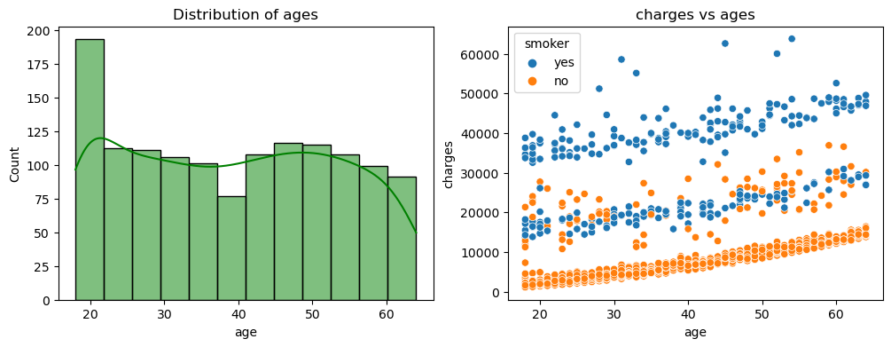

```python
plt.figure(figsize=(12,4))

plt.subplot(1,2,1)
sns.histplot(df["age"],kde=True,color="green")
plt.title("Distribution of ages")

plt.subplot(1,2,2)
sns.scatterplot(data = df, x = "age",y = "charges", hue="smoker")
plt.title("charges vs ages")

plt.show()
```

## > We can also see that the charges increases along with the age of people.

## > from the above we can observe that the charges are quite high for people who smoke compared to those who don't.

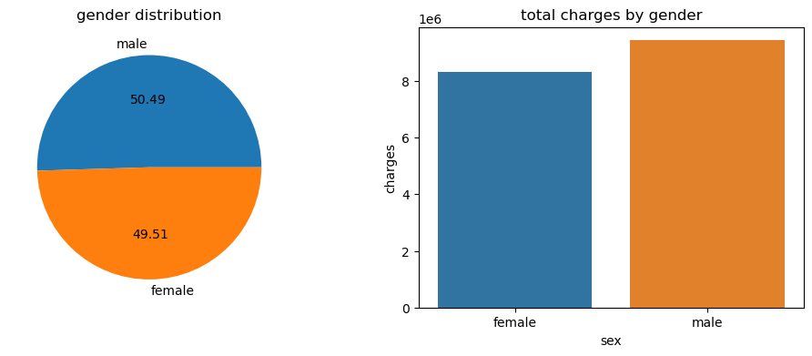

```python
plt.figure(figsize=(12,4))

plt.subplot(1,2,1)
plt.pie(df["sex"].value_counts(),autopct="%.2f",labels=df["sex"].value_counts().index)
plt.title("gender distribution")

plt.subplot(1,2,2)
sns.barplot(x=df.groupby("sex")["charges"].sum().index,y=df.groupby("sex")["charges"].sum())
plt.title("total charges by gender")

plt.show()
```

```python
df.groupby("sex")["charges"].sum().index,df.groupby("sex")["charges"].sum().values
```

```
(Index(['female', 'male'], dtype='object', name='sex'),
 array([8321061.194619, 9433124.23304 ]))
```

## > From the above we can observe that male people are more than female people.

## > another observation is that we can observe that male are paying more in total for charges compared with women.

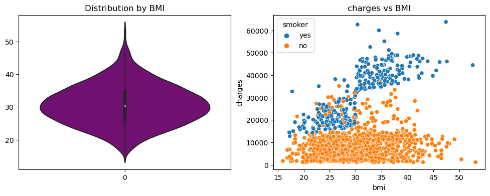

```python
plt.figure(figsize=(12,4))

plt.subplot(1,2,1)
sns.violinplot(df["bmi"],kde=True,color="purple")
plt.title("Distribution by BMI")

plt.subplot(1,2,2)
sns.scatterplot(data = df, x = "bmi",y = "charges", hue="smoker")
plt.title("charges vs BMI")
plt.show()
```

## > From the above we can say that most of the people have an average BMI of 30

## > We can also observe that people with the same BMI but are smoking are getting chareged more in comparision to people who don't smoke

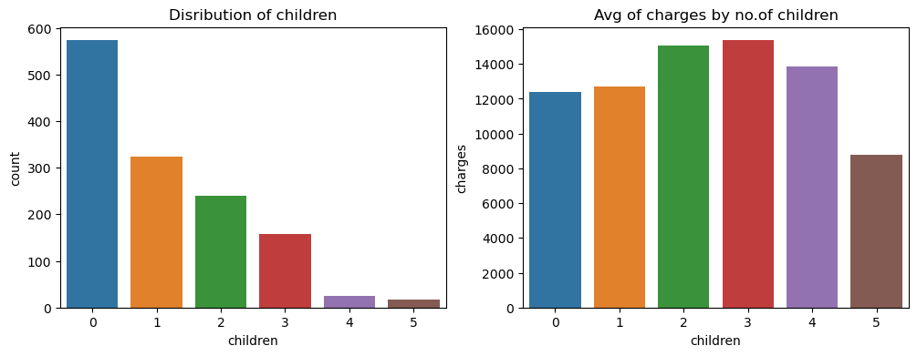

```python
plt.figure(figsize=(12,4))

plt.subplot(1,2,1)
sns.barplot(x=df["children"].value_counts().index,y=df["children"].value_counts())
plt.title("Disribution of children")

plt.subplot(1,2,2)
sns.barplot(x=df.groupby("children")["charges"].mean().index,y=df.groupby("children")["charges"].mean())
plt.title("Avg of charges by no.of children")
plt.show()
```

```python
df.groupby("children")["charges"].agg(["mean","sum"])
```

| children | mean | sum |
| --- | --- | --- |
| 0 | 12384.695344 | 7.096430e+06 |
| 1 | 12731.171832 | 4.124900e+06 |
| 2 | 15073.563734 | 3.617655e+06 |
| 3 | 15355.318367 | 2.410785e+06 |
| 4 | 13850.656311 | 3.462664e+05 |
| 5 | 8786.035247 | 1.581486e+05 |

## > From the above observations we can say that people with no children are more in number and because of that they're the highest contributors to the total charges paid.

## > We can observe that a families with 2 or 3 children are paying the highest charges compared to rest of the families.

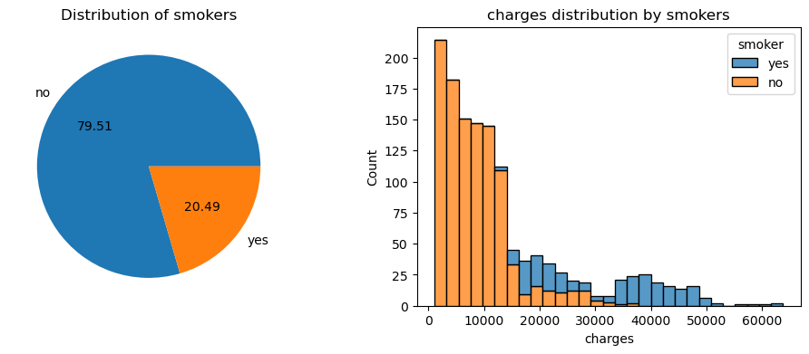

```python
plt.figure(figsize=(12,4))

plt.subplot(1,2,1)
plt.pie(df["smoker"].value_counts(),labels=df["smoker"].value_counts().index,autopct="%.2f")
plt.title("Distribution of smokers")

plt.subplot(1,2,2)
sns.histplot(data=df,x="charges",hue="smoker",multiple='stack')
plt.title("charges distribution by smokers")
plt.show()
```

## > From the above we can observe that around 80 percent of people are non smokers.

## > We can observe that smoking individuals are paying more charges compared to non-smokers.

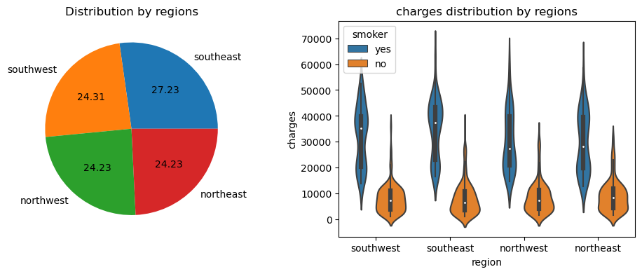

```python
plt.figure(figsize=(12,4))

plt.subplot(1,2,1)
plt.pie(df["region"].value_counts(),labels=df["region"].value_counts().index,autopct="%.2f")
plt.title("Distribution by regions")

plt.subplot(1,2,2)
sns.violinplot(data=df,x="region",y="charges",multiple="stack",hue="smoker")
plt.title("charges distribution by regions")
plt.show()
```

```python
df.groupby(["region","sex"])["charges"].agg(["sum","mean"])
```

| region | sex | sum | mean |
| --- | --- | --- | --- |
| northeast | female | 2.085466e+06 | 12953.203151 |
|  | male | 2.258203e+06 | 13854.005374 |
| northwest | female | 2.046699e+06 | 12479.870397 |
|  | male | 1.987374e+06 | 12421.085553 |
| southeast | female | 2.362442e+06 | 13499.669243 |
|  | male | 3.001248e+06 | 15879.617173 |
| southwest | female | 1.826455e+06 | 11274.411264 |
|  | male | 2.186300e+06 | 13412.883576 |

## > From the above we can observe that the people from the southeast region are paying more charges be it male or female compared to the rest of the regions.

## > We can say that the rest of the 3 regions have almost same charges.

```python
df.columns
```

```
Index(['age', 'sex', 'bmi', 'children', 'smoker', 'region', 'charges'], dtype='object')
```

```python
sample_df = df.select_dtypes(include=["int64","float64"])
sample_df
```

|  | age | bmi | children | charges |
| --- | --- | --- | --- | --- |
| 0 | 19 | 27.900 | 0 | 16884.92400 |
| 1 | 18 | 33.770 | 1 | 1725.55230 |
| 2 | 28 | 33.000 | 3 | 4449.46200 |
| 3 | 33 | 22.705 | 0 | 21984.47061 |
| 4 | 32 | 28.880 | 0 | 3866.85520 |
| ... | ... | ... | ... | ... |
| 1332 | 50 | 30.970 | 3 | 10600.54830 |
| 1333 | 18 | 31.920 | 0 | 2205.98080 |
| 1334 | 18 | 36.850 | 0 | 1629.83350 |
| 1335 | 21 | 25.800 | 0 | 2007.94500 |
| 1336 | 61 | 29.070 | 0 | 29141.36030 |

1337 rows × 4 columns

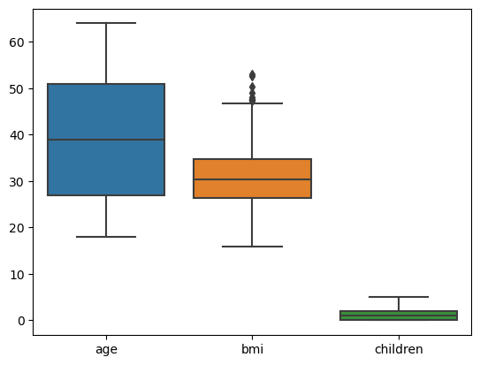

```python
sns.boxplot(sample_df.iloc[:,:3])
```

## > From the above we can observe that there exists outliers in bmi column

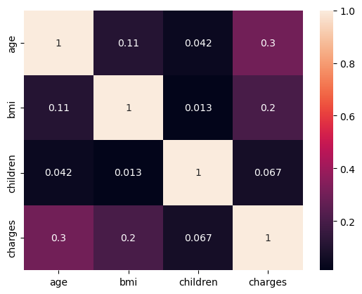

```python
sns.heatmap(sample_df.corr(),annot=True)
```

## > From the above we can observe that age and charges have a positive correlation

## Step - 2: Document the below mentioned points properly:

```
- Identify the input and output/target variables.
- Identify the type of ML Task.
- Identify the Evaluation Metric.
    - For regression task - Mean Absolute Error
    - For classification task - Accuracy
```

## Identifying the target columns

```python
Y = df["charges"]
X = df[['age', 'sex', 'bmi', 'children', 'smoker', 'region']]
```

## Step - 3: Split the dataset into Training and Testing (recommended 75:25 split).

```python
from sklearn.model_selection import train_test_split as split
```

## Train Test splitting

```python
X_train,X_test,Y_train,Y_test = split(X,Y,train_size=0.75, random_state = 83)
```

```python
print(X_train.shape ,Y_train.shape)

print(X_test.shape ,Y_test.shape)
```

```
(1002, 6) (1002,)
(335, 6) (335,)
```

## Step - 4: Data preparation on train data:

## For Numerical Variables - RobustScaler (Fit and Transform)

```python
X_train_num = X_train.select_dtypes(include=["int64","float64"])
X_train_num
```

|  | age | bmi | children |
| --- | --- | --- | --- |
| 148 | 53 | 37.430 | 1 |
| 1266 | 24 | 31.065 | 0 |
| 554 | 25 | 41.325 | 0 |
| 721 | 62 | 37.400 | 0 |
| 1325 | 42 | 32.870 | 0 |
| ... | ... | ... | ... |
| 1320 | 62 | 26.695 | 0 |
| 1334 | 18 | 36.850 | 0 |
| 1280 | 47 | 27.645 | 2 |
| 1000 | 24 | 32.700 | 0 |
| 82 | 22 | 37.620 | 1 |

1002 rows × 3 columns

```python
from sklearn.preprocessing import RobustScaler

Rbs = RobustScaler()

X_train_num_rescaled = pd.DataFrame(Rbs.fit_transform(X_train_num),
                                   columns=X_train_num.columns,
                                   index = X_train_num.index)

X_train_num_rescaled.head()
```

|  | age | bmi | children |
| --- | --- | --- | --- |
| 148 | 0.583333 | 0.826399 | 0.0 |
| 1266 | -0.625000 | 0.095839 | -0.5 |
| 554 | -0.583333 | 1.273458 | -0.5 |
| 721 | 0.958333 | 0.822956 | -0.5 |
| 1325 | 0.125000 | 0.303013 | -0.5 |

## For Categorical - LabelEncoding or OneHotEncoding

```python
X_train_cat = X_train.select_dtypes(include=["object"])

X_train_cat
```

|  | sex | smoker | region |
| --- | --- | --- | --- |
| 148 | female | no | northwest |
| 1266 | male | yes | northeast |
| 554 | female | no | northeast |
| 721 | male | no | southwest |
| 1325 | female | no | northeast |
| ... | ... | ... | ... |
| 1320 | male | yes | northeast |
| 1334 | female | no | southeast |
| 1280 | female | yes | northwest |
| 1000 | male | yes | southwest |
| 82 | male | yes | southeast |

1002 rows × 3 columns

```python
from sklearn.preprocessing import OneHotEncoder

ohe = OneHotEncoder(drop = "first",sparse_output=False)

X_train_cat_ohe = pd.DataFrame(ohe.fit_transform(X_train_cat),
                               columns = ohe.get_feature_names_out(X_train_cat.columns),
                               index = X_train_cat.index)

X_train_cat_ohe.head()
```

|  | sex_male | smoker_yes | region_northwest | region_southeast | region_southwest |
| --- | --- | --- | --- | --- | --- |
| 148 | 0.0 | 0.0 | 1.0 | 0.0 | 0.0 |
| 1266 | 1.0 | 1.0 | 0.0 | 0.0 | 0.0 |
| 554 | 0.0 | 0.0 | 0.0 | 0.0 | 0.0 |
| 721 | 1.0 | 0.0 | 0.0 | 0.0 | 1.0 |
| 1325 | 0.0 | 0.0 | 0.0 | 0.0 | 0.0 |

## Concatinating the dataframes

```python
x_train_transformed=pd.concat([X_train_cat_ohe,X_train_num_rescaled],axis=1)
x_train_transformed
```

|  | sex_male | smoker_yes | region_northwest | region_southeast | region_southwest | age | bmi | children |
| --- | --- | --- | --- | --- | --- | --- | --- | --- |
| 148 | 0.0 | 0.0 | 1.0 | 0.0 | 0.0 | 0.583333 | 0.826399 | 0.0 |
| 1266 | 1.0 | 1.0 | 0.0 | 0.0 | 0.0 | -0.625000 | 0.095839 | -0.5 |
| 554 | 0.0 | 0.0 | 0.0 | 0.0 | 0.0 | -0.583333 | 1.273458 | -0.5 |
| 721 | 1.0 | 0.0 | 0.0 | 0.0 | 1.0 | 0.958333 | 0.822956 | -0.5 |
| 1325 | 0.0 | 0.0 | 0.0 | 0.0 | 0.0 | 0.125000 | 0.303013 | -0.5 |
| ... | ... | ... | ... | ... | ... | ... | ... | ... |
| 1320 | 1.0 | 1.0 | 0.0 | 0.0 | 0.0 | 0.958333 | -0.405739 | -0.5 |
| 1334 | 0.0 | 0.0 | 0.0 | 1.0 | 0.0 | -0.875000 | 0.759828 | -0.5 |
| 1280 | 0.0 | 1.0 | 1.0 | 0.0 | 0.0 | 0.333333 | -0.296700 | 0.5 |
| 1000 | 1.0 | 1.0 | 0.0 | 0.0 | 1.0 | -0.625000 | 0.283501 | -0.5 |
| 82 | 1.0 | 1.0 | 0.0 | 1.0 | 0.0 | -0.708333 | 0.848207 | 0.0 |

1002 rows × 8 columns

## Step - 5: Data preparation on test data:

```python
X_test_num = X_test.select_dtypes(include=['int64', 'float64'])

X_test_num.head()
```

|  | age | bmi | children |
| --- | --- | --- | --- |
| 1279 | 48 | 33.33 | 0 |
| 1282 | 18 | 30.03 | 1 |
| 84 | 37 | 34.80 | 2 |
| 244 | 63 | 27.74 | 0 |
| 779 | 30 | 24.40 | 3 |

## For Numerical Variables - RobustScaler (Transform)

```python
X_test_num_rescaled = pd.DataFrame(Rbs.transform(X_test_num),
                                    columns = X_test_num.columns,
                                    index = X_test_num.index)

X_test_num_rescaled.head()
```

|  | age | bmi | children |
| --- | --- | --- | --- |
| 1279 | 0.375000 | 0.355811 | -0.5 |
| 1282 | -0.875000 | -0.022956 | 0.0 |
| 84 | -0.083333 | 0.524534 | 0.5 |
| 244 | 1.000000 | -0.285796 | -0.5 |
| 779 | -0.375000 | -0.669154 | 1.0 |

```python
X_test_cat = X_test.select_dtypes(include=['object'])

X_test_cat.head()
```

|  | sex | smoker | region |
| --- | --- | --- | --- |
| 1279 | female | no | southeast |
| 1282 | male | no | southeast |
| 84 | female | yes | southwest |
| 244 | female | yes | northeast |
| 779 | male | yes | southwest |

## For Categorical - LabelEncoding or OneHotEncoding

```python
X_test_cat_ohe = pd.DataFrame(ohe.transform(X_test_cat),
                               columns=ohe.get_feature_names_out(X_test_cat.columns),
                               index = X_test_cat.index)

X_test_cat_ohe.head()
```

|  | sex_male | smoker_yes | region_northwest | region_southeast | region_southwest |
| --- | --- | --- | --- | --- | --- |
| 1279 | 0.0 | 0.0 | 0.0 | 1.0 | 0.0 |
| 1282 | 1.0 | 0.0 | 0.0 | 1.0 | 0.0 |
| 84 | 0.0 | 1.0 | 0.0 | 0.0 | 1.0 |
| 244 | 0.0 | 1.0 | 0.0 | 0.0 | 0.0 |
| 779 | 1.0 | 1.0 | 0.0 | 0.0 | 1.0 |

```python
x_test_transformed=pd.concat([X_test_cat_ohe,X_test_num_rescaled],axis=1)
x_test_transformed
```

|  | sex_male | smoker_yes | region_northwest | region_southeast | region_southwest | age | bmi | children |
| --- | --- | --- | --- | --- | --- | --- | --- | --- |
| 1279 | 0.0 | 0.0 | 0.0 | 1.0 | 0.0 | 0.375000 | 0.355811 | -0.5 |
| 1282 | 1.0 | 0.0 | 0.0 | 1.0 | 0.0 | -0.875000 | -0.022956 | 0.0 |
| 84 | 0.0 | 1.0 | 0.0 | 0.0 | 1.0 | -0.083333 | 0.524534 | 0.5 |
| 244 | 0.0 | 1.0 | 0.0 | 0.0 | 0.0 | 1.000000 | -0.285796 | -0.5 |
| 779 | 1.0 | 1.0 | 0.0 | 0.0 | 1.0 | -0.375000 | -0.669154 | 1.0 |
| ... | ... | ... | ... | ... | ... | ... | ... | ... |
| 948 | 1.0 | 1.0 | 0.0 | 0.0 | 1.0 | -0.583333 | -0.060832 | 1.0 |
| 598 | 0.0 | 0.0 | 1.0 | 0.0 | 0.0 | 0.541667 | 0.837303 | 0.5 |
| 175 | 0.0 | 1.0 | 0.0 | 0.0 | 1.0 | 1.000000 | 0.857389 | -0.5 |
| 1319 | 1.0 | 0.0 | 1.0 | 0.0 | 0.0 | -0.333333 | 0.095839 | 1.0 |
| 827 | 1.0 | 1.0 | 0.0 | 0.0 | 0.0 | 0.083333 | 0.063128 | 1.0 |

335 rows × 8 columns

## Step - 6: Model Training Phase - Use all the algorithms mentioned below to train separate models:

```
- KNN
- Logistic Regression / Linear Regression
- Support Vector Machines
- Decision Trees
- Random Forest
```

```python
from sklearn.metrics import mean_absolute_error
```

## KNN

```python
from sklearn.neighbors import KNeighborsRegressor
KNN_REG = KNeighborsRegressor()
KNN_REG.fit(x_train_transformed,Y_train)
```

```
KNeighborsRegressor()
```

```python
y_test_predicted = KNN_REG.predict(x_test_transformed)
```

```python
KN_mean = mean_absolute_error(Y_test,y_test_predicted)
KN_mean
```

```
3854.5024967516424
```

## Linear Regression

```python
from sklearn.linear_model import LinearRegression
LR_REG = LinearRegression()
LR_REG.fit(x_train_transformed,Y_train)
```

```
LinearRegression()
```

```python
y_test_predicted = LR_REG.predict(x_test_transformed)
```

```python
LR_mean = mean_absolute_error(Y_test,y_test_predicted)
LR_mean
```

```
4323.963298005765
```

## Support Vector Regression (SVR)

```python
from sklearn.svm import SVR
SV_REG = SVR()
SV_REG.fit(x_train_transformed,Y_train)
```

```
SVR()
```

```python
y_test_predicted = SV_REG.predict(x_test_transformed)
```

```python
SV_mean = mean_absolute_error(Y_test,y_test_predicted)
SV_mean
```

```
9114.819320723118
```

## Decision Tree Regression

```python
from sklearn.tree import DecisionTreeRegressor
DT_REG = DecisionTreeRegressor()
DT_REG.fit(x_train_transformed,Y_train)
```

```
DecisionTreeRegressor()
```

```python
y_test_predicted = DT_REG.predict(x_test_transformed)
```

```python
DT_mean = mean_absolute_error(Y_test,y_test_predicted)
DT_mean
```

```
3057.49299680597
```

## Random Forest Regressor

```python
from sklearn.ensemble import RandomForestRegressor
RF_REG = RandomForestRegressor()
RF_REG.fit(x_train_transformed,Y_train)
```

```
RandomForestRegressor()
```

```python
y_test_predicted = RF_REG.predict(x_test_transformed)
```

```python
RF_mean = mean_absolute_error(Y_test,y_test_predicted)
RF_mean
```

```
2728.6004191411694
```

## Step - 7: Predict and evaluate each model separately using the correct evaluation metric.

```python
reg_models = ["LinearRegression()",
             "KNeighborsRegressor()",
             "DecisionTreeRegressor()",
             "RandomForestRegressor()",
             "SVR()"]

mean_results=[LR_mean,KN_mean,DT_mean,RF_mean,SV_mean]

result_df = pd.DataFrame({"Algorithm":reg_models,"MAE":mean_results})
result_df
```

|  | Algorithm | MAE |
| --- | --- | --- |
| 0 | LinearRegression() | 4323.963298 |
| 1 | KNeighborsRegressor() | 3854.502497 |
| 2 | DecisionTreeRegressor() | 3057.492997 |
| 3 | RandomForestRegressor() | 2728.600419 |
| 4 | SVR() | 9114.819321 |

## We can observe that out of all the models that we've trained, the Random Forest Regressor model is giving the lowest mean absolute error, which means predictions made by this model are the closest to the real values in comparison to the other models. So, we can say that by observing the evaluation metric of all models that the Random Forest Regressor is the best algorithm for the Medical Cost Prediction problem.